# Incarceration

Saranya Gores

2/24/2022

## Introduction

Racial inequality is a problem that is well known in the US, but the depths of racial inequality are not necessarily well understood. This project will take a look at existing data for prison populations based on race, and investigate potential trends of racial bias/inequality. The project will use prison data published by the Vera Institute. Not all states have up to date data. The most recent data is from 2016.

## Summary Information

This section will explore some high level information about prison rates within the country. Across the entire nation, roughly 0.60% of the population is in prison in 2016. The state with the highest prison rate is Oklahoma at a rate of ~1.1%, nearly double that of the national average.

In 2016,white people in America have a national prison rate of ~0.40%. Black people have a national prison rate of ~1.83%. Hispanic people have a national prison rate of ~0.55%. Native Americans have a national prison rate of ~1.17%, Asian Americans + Pacific Islanders have a national prison rate of ~0.05%.

These trends show potential bias against mainly Black, Native American, and Hispanic people within America.

1. The average percentage of population in jail across all the counties in 2016.

```
## [1] 0.598
```

2. The State with the highest number of jail population and it’s prison population percentage.

```
## 1.066
##  "OK"
```

3. The national prison rate for White people in 2016.

```
## [1] 0.401
```

4. The national prison rate for Black people in 2016.

```
## [1] 1.831
```

5. The national prison rate for Hispanic people in 2016.

```
## [1] 0.554
```

6. The national prison rate for Native Americans in 2016.

```
## [1] 1.172
```

7. The national prison rate for Asian Americans / Pacific Islanders in 2016.

```
## [1] 0.047
```

## Charts

### Chart 1 : National Jail Rate per 10,000 population from 1990 to 2016

What this tells us is that Black, Hispanic, and Native Americans in America are probably over imprisoned due to their high prison rate However, this trend has been improving for Black and Hispanic people when compared to 1990.Native Americans continue to be shown increasing prejudice from the justice system into 2016 onwards.

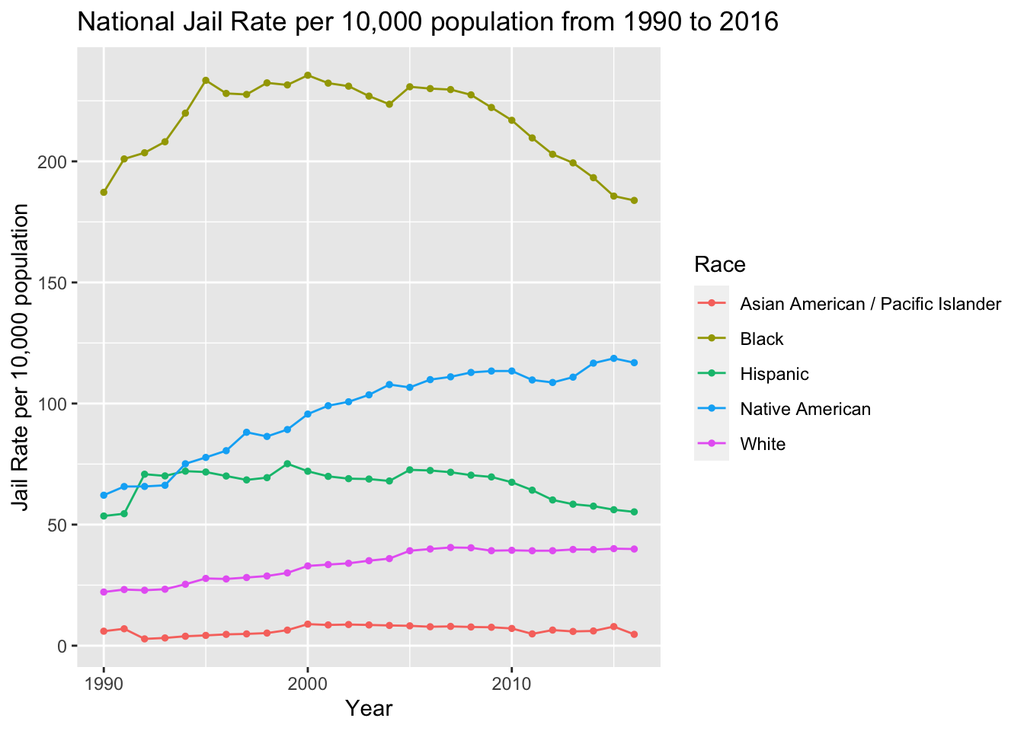

### Chart 2 : Total Prison Population vs. Prison Rate by Race 2016

Next, we will try to see if there is any correlation with the number of prisoners and the makeup of prisoners by race in 2016. This chart will plot the prison rate for each race for each jail in America that has at least 100 prisoners in it. We’ll draw trendlines to see if there is a correlation between prison size and the population of prisoners being a certain race. What we see is a positive correlation between prison size and the percentage of prisoners being black or hispanic. There is a negative correlation between prison size and percentage of prisoners for the other races captured in this data. What this suggests is that the increase in prison population is a result of more black and Hispanic people being imprisoned, which also suggests that these groups of people are targeted and overprisoned within America.

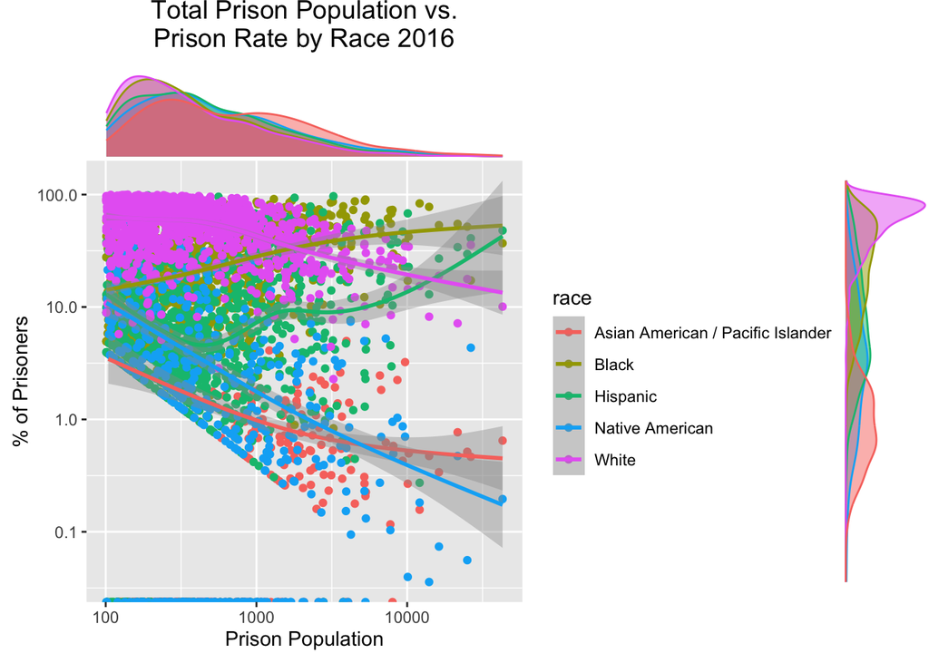

### Chart 3 : Geographical View of Prison Population 2016

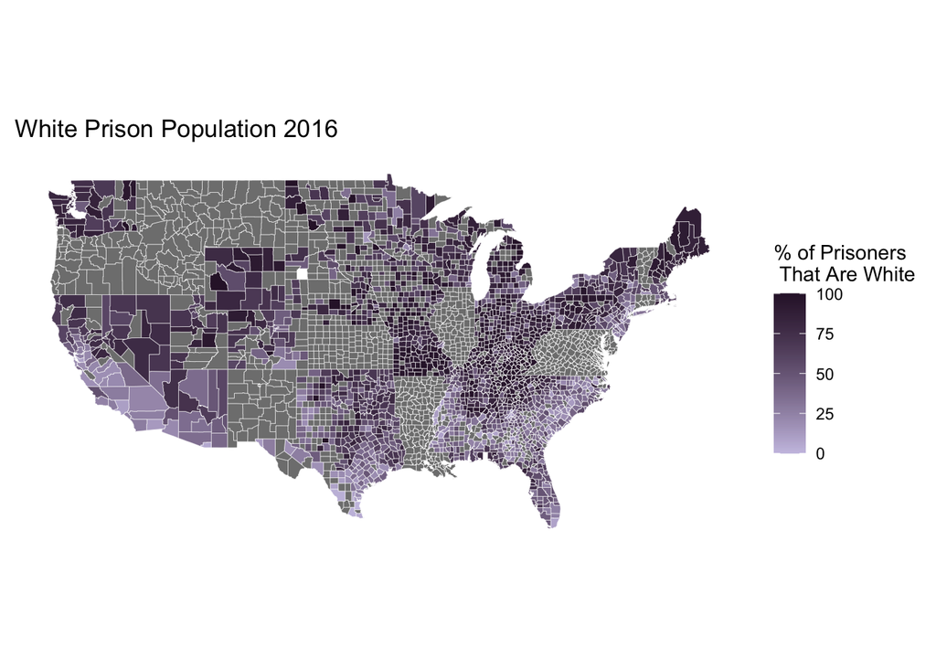

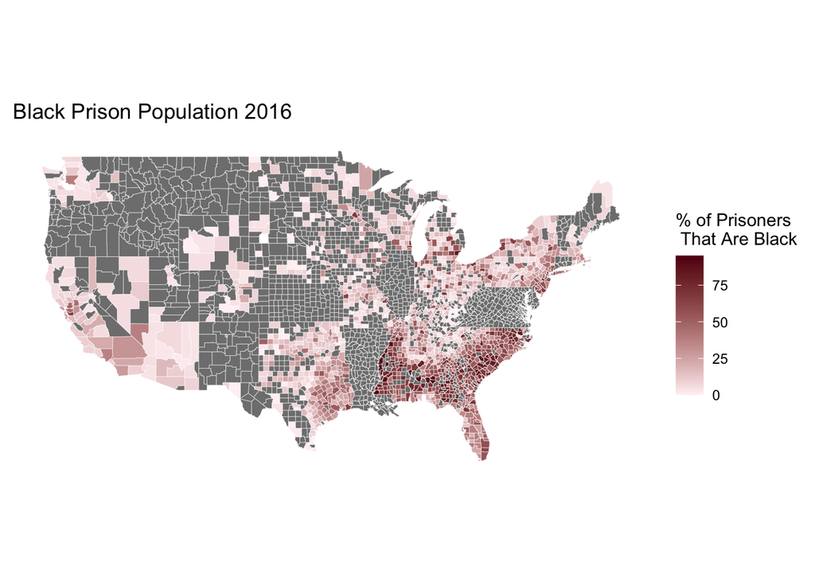

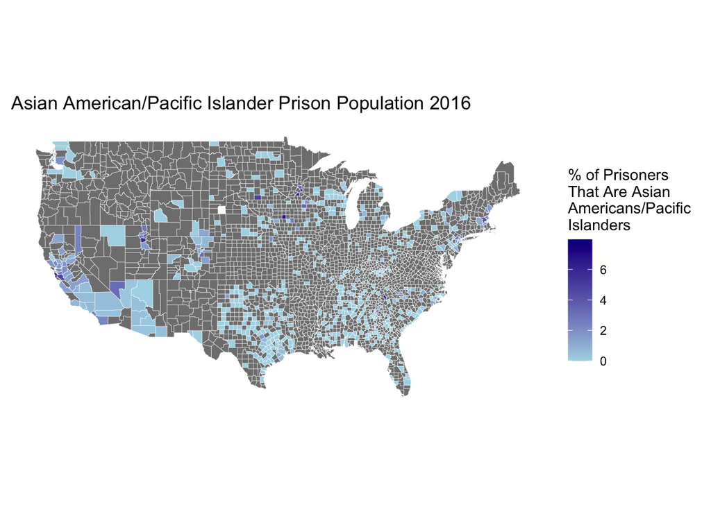

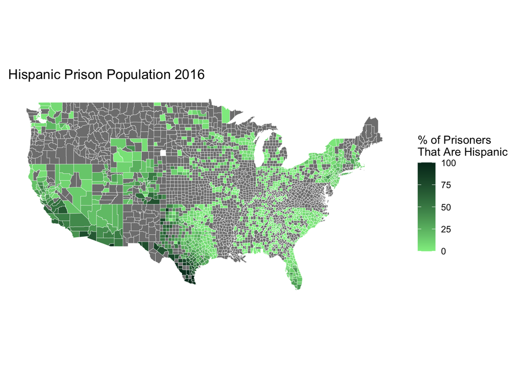

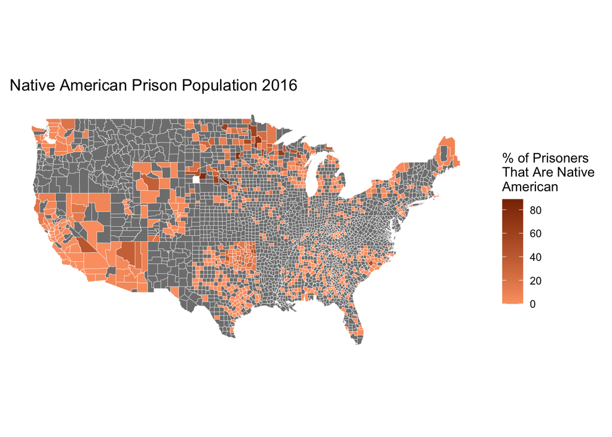